# Homework 4

Please upload an html/pdf to Sakai by Wednesday, October 1, at 6 pm.

1. Consider the attached rds files:
- X1.rds, containing the model matrix of a reduced model with a single explanatory variable ($X_1$)
- X2.rds, containing the model matrix of a full model with two explanatory variables, one numeric ($X_1$) and one categorical ($X_2$)
- y.rds, containing the observations of a response variable ($y$)

**Note**: you can use the function readRDS in R to upload these types of data files (the syntax is otherwise the same)

1. Using linear algebra, perform a formal hypothesis test to determine if the variable $X_1$ and $y$ have a statistically significant linear relationship.

   Reduced Model: $\hat{Y} = \beta_0$

   Full Model: $\hat{Y} = \beta_0 + \beta_1X$

   $H_0: \beta_1 = 0, H_a: \beta_1 \neq 0$

   Therefore we can reject the null hypothesis and say that $\beta_1 \neq 0$ and the variable $X_1$ and $y$ have a statistically significant linear relationship.

```r
X1 <- readRDS("Data/X1.rds")
X2 <- readRDS("Data/X2.rds")
y  <- readRDS("Data/y.rds")

X1 <- as.matrix(X1)
X2 <- as.matrix(X2)
y  <- as.matrix(y)

n1  <- nrow(X1)
p1 <- ncol(X1)

XtX_1    <- t(X1) %*% X1
XtX_1inv <- solve(XtX_1)
P1       <- X1 %*% XtX_1inv %*% t(X1)

yhat1 <- P1 %*% y
resid1 <- y - yhat1

SSE1 <- (t(resid1) %*% resid1)

sigma2_hat_1 <- SSE1 / (n1 - p1)

beta_hat_1 <- XtX_1inv %*% (t(X1) %*% y)
Var_beta_1 <- as.numeric(sigma2_hat_1) * XtX_1inv

t_stat <- (beta_hat_1[2,1] / sqrt(Var_beta_1[2,2]))
df     <- n1 - p1
p_val  <- 2 * (1 - pt(abs(t_stat), df))

t_stat
```

```
      X
3.25783
```

```r
p_val
```

```
          X
0.001543219
```

2. Using linear algebra, find the proportion of variation in $y$ that is explained by a linear model with $X_1$ and $X_2$.

   $r^2 = 0.1911$ , meaning 19.11% of the proportion of variation in y is explained by a linear model with both $X1$ and $X2$

```r
BX2 <- solve(t(X2) %*% X2) %*% t(X2) %*% y
ybar <- mean(y)
SSEX2 <- t(y - X2 %*% BX2) %*% (y - X2 %*% BX2)
SSTX2 <- sum((y - ybar)^2)
SSMX2 <- SSTX2 - SSEX2
R2X2 <- SSMX2 / SSTX2

R2X2
```

```
        [,1]
[1,] 0.19106
```

3. Assume that the linear model in (a) is statistically significant. Using linear algebra, perform a formal hypothesis test to determine if adding the variable $X_2$ to the linear model in (a) is statistically significant.

   Reduced Model: $\hat{Y} = \beta_0 + \beta_1 X1$

   Full Model: $\hat{Y} = \beta_0 + \beta_1 X1 + \beta_2 X2$

   $H_0: \beta_2 = 0, H_a: \beta_2 \neq 0$

   $F = 5.54, p = 0.0053$ , therefore we reject the null hypothesis and can conclude that adding $X2$ as an explanatory variable to a linear model that already includes $y$ as a response variable and $X1$ as an explanatory variable.

```r
n  <- nrow(X1)
pR <- ncol(X1)
pF <- ncol(X2)
q  <- pF - pR
I  <- diag(n)

PR <- X1 %*% solve(t(X1) %*% X1) %*% t(X1)
PF <- X2 %*% solve(t(X2) %*% X2) %*% t(X2)

SSE_R <- as.numeric(t(y) %*% (I - PR) %*% y)
SSE_F <- as.numeric(t(y) %*% (I - PF) %*% y)

num <- (SSE_R - SSE_F) / q
den <- SSE_F / (n - pF)
f   <- num / den
p <- 1 - pf(f, q, n - pF)

f
```

```
[1] 5.538642
```

```r
p
```

```
[1] 0.005291108
```

```r
#check to make sure
modred <- lm(y ~ X1)
modfull <- lm(y ~ X2)
anova(modred, modfull)
```

```
Analysis of Variance Table

Model 1: y ~ X1
Model 2: y ~ X2
  Res.Df    RSS Df Sum of Sq      F   Pr(>F)
1     98 758.97
2     96 680.45  2    78.517 5.5386 0.005291 **
---
Signif. codes:  0 '***' 0.001 '**' 0.01 '*' 0.05 '.' 0.1 ' ' 1
```

```r
# yup we good
```

4. For the model that you choose in (b), determine if there are any influential observations.

   From the studentized values of the linear relationship of y and X1 and X2, we can determine that observations 11 and 73 are influential observations.

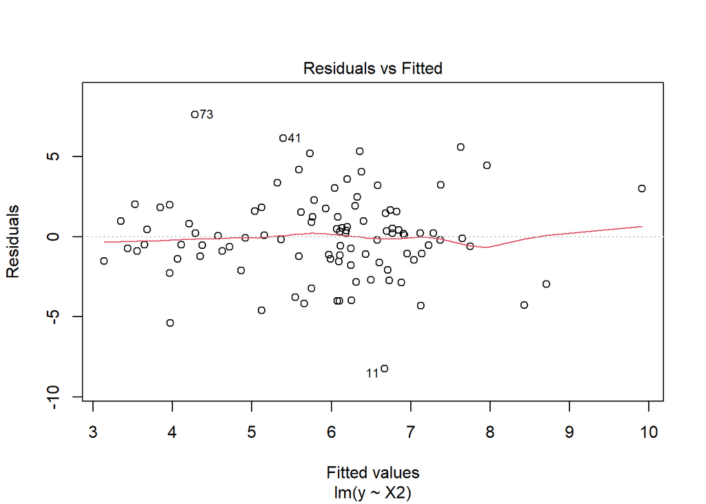

```r
# From class convo it is clear you wanted linear but I did rstud() method first

# initial observation
plot(modfull,1) #modfull is y ~ XZ (above)
```

```r
# obs 11 is an influential observation, 73
rstud <- rstudent(modfull)
id1 <- which.max(abs(rstud))
n <- nrow(X2)
k <- 4
alpha <- 0.01
crit <- qt(1-alpha/2,n-k-1)
(abs(rstud)[id1] > crit)
```

```
  11
TRUE
```

```r
# observation 73 is our next influential observation
modfull2 <- lm(y[-11,] ~ X2[-11, -1])
rstud2 <- rstudent(modfull2)
id2 <- which.max(abs(rstud2))
abs(rstud2)[id2] > crit
```

```
  72
TRUE
```

```r
# next one 42 is not an influential observation
infl_obs <- c(11,73)
modfull3 <- lm(y[-infl_obs,] ~ X2[-infl_obs, -1])
rstud3 <- rstudent(modfull3)
id3 <- which.max(abs(rstud3))
abs(rstud3)[id3] > crit
```

```
   40
FALSE
```

```r
# LINEAR

# first test, 11 is influential
hat_mat <- X2 %*% solve(t(X2) %*% X2) %*% t(X2)
yhatx2 <- X2 %*% BX2
errorest <- y - yhatx2
lev <- diag(hat_mat)
MSEX2 <- SSEX2 / (nrow(X2) - k)
stud_resid <- errorest / sqrt(as.numeric(MSEX2)) * sqrt(1 - lev)
id4 <- which.max(abs(stud_resid))
id4
```

```
[1] 11
```

```r
abs(stud_resid)[id4] > crit
```

```
[1] TRUE
```

```r
# 11 is true

#second test, 73 is influential
X2_rm11 <- X2[-11,]
hat_mat <- X2_rm11 %*% solve(t(X2_rm11) %*% X2_rm11) %*% t(X2_rm11)
yhatx2 <- X2_rm11 %*% BX2
errorest <- y[-11,] - yhatx2
lev <- diag(hat_mat)
MSEX2 <- SSEX2 / (nrow(X2_rm11) - k)
stud_resid <- errorest / sqrt(as.numeric(MSEX2)) * sqrt(1 - lev)
id5 <- which.max(abs(stud_resid))
id5
```

```
[1] 72
```

```r
abs(stud_resid)[id5] > crit
```

```
[1] TRUE
```

```r
#third test
inf <- c(11,73)
X2_rm_inf <- X2[-inf,]
hat_mat <- X2_rm_inf %*% solve(t(X2_rm_inf) %*% X2_rm_inf) %*% t(X2_rm_inf)
yhatx2 <- X2_rm_inf %*% BX2
errorest <- y[-inf] - yhatx2
lev <- diag(hat_mat)
MSEX2 <- SSEX2 / (nrow(X2_rm_inf) - k)
stud_resid <- errorest / sqrt(as.numeric(MSEX2)) * sqrt(1 - lev)
id6 <- which.max(abs(stud_resid))
id6
```

```
[1] 40
```

```r
abs(stud_resid)[id6] > crit
```

```
[1] FALSE
```